# dwb284_assignment_7

Textbook: Page 416, Question 9*, parts (a) through (g), (k), and (l). (using R)

For part (l), make sure to use model.matrix() to compare the design matrix from lm() with the corresponding matrix of part (a). a. The null hypothesis is that beta1 through beta6 all equal 0. That is, that there is no correlation between any of these variables and the average SO2 concentration in each city. The alternative hypothesis is that at least one of the beta.hats are not equal to 0. H0:β1 = β2 = β3 = β4 = β5 = β6 = 0 HA: not all βk equal 0.

```r
library(asbio)
data(so2.us.cities)
Y<-SO2<-so2.us.cities$Y
avg_ann_temp<-so2.us.cities$X1
large_industrial_companies<-so2.us.cities$X2
pop_size<-so2.us.cities$X3
avg_wind_speed<-so2.us.cities$X4
avg_precip<-so2.us.cities$X5
avg_dry_days<-so2.us.cities$X6
X <- cbind(rep(1, nrow(so2.us.cities[,3:8])), avg_ann_temp,large_industrial_companies,pop_size,avg_wind_speed,avg_precip,avg_dry_days)
#b
beta.hat <- solve(t(X) %*% X) %*% t(X) %*% SO2
beta.hat
```

```
##                                    [,1]
##                            113.79004167
## avg_ann_temp                -1.16748383
## large_industrial_companies   0.05437428
## pop_size                    -0.02752411
## avg_wind_speed              -4.11045229
## avg_precip                   0.41696158
## avg_dry_days                -0.04833085
```

```r
#c.
y.hat = X %*% beta.hat
y.hat
```

```
##             [,1]
##  [1,]   3.815575
##  [2,]  25.580588
##  [3,]  22.133322
##  [4,]  27.957768
##  [5,]  49.471516
##  [6,]  27.172845
##  [7,]  22.279613
##  [8,]   7.702336
##  [9,]   9.433796
## [10,]  25.512800
## [11,] 109.529328
## [12,]  22.260441
## [13,]  18.554036
## [14,]   3.467876
```

[output cut: 18 more lines]

```r
#d.
p <- ncol(so2.us.cities)-1
n <- length(Y)
SSR = t(beta.hat) %*% t(X) %*% Y - (1/n)*t(Y) %*% matrix(1, 32,32) %*% Y
SSR
```

```
##          [,1]
## [1,] 11841.25
```

```r
#e.
SSE = t(Y) %*% Y - t(beta.hat) %*% t(X) %*% Y
SSE
```

```
##          [,1]
## [1,] 2640.253
```

```r
#f.
MSR <- SSR / (p-1)
MSE <- SSE / (n-p)
F.star <- MSR/MSE
p_value <- pf(F.star,p-1,n-p, lower.tail=FALSE)
p_value
```

```
##              [,1]
## [1,] 3.895529e-08
```

```r
#g.
e = Y-y.hat
e
```

```
##              [,1]
##  [1,]   6.1844252
##  [2,] -12.5805881
##  [3,] -10.1333216
##  [4,] -10.9577685
##  [5,]   6.5284835
##  [6,]   8.8271546
##  [7,]   6.7203875
##  [8,]   6.2976640
##  [9,]   0.5662036
## [10,]  -1.5128000
## [11,]   0.4706715
## [12,]   5.7395593
## [13,]  -1.5540357
## [14,]   4.5321240
```

[output cut: 18 more lines]

```r
#k.
sigma.sq.beta.hat <- MSE[1] * solve(t (X) %*% X)
s.beta.hat <- sqrt(diag(sigma.sq.beta.hat))
t.stars_vector <- beta.hat/s.beta.hat
t.stars_vector
```

```
##                                  [,1]
##                             3.2835573
## avg_ann_temp               -2.5628274
## large_industrial_companies  4.6965625
## pop_size                   -2.4347239
## avg_wind_speed             -2.7670883
## avg_precip                  1.4999636
## avg_dry_days               -0.3893373
```

```r
pvalues_vector<- 2 * pt(abs(t.stars_vector), n - p, lower.tail=FALSE)
pvalues_vector
```

```
##                                    [,1]
##                            3.025639e-03
## avg_ann_temp               1.678624e-02
## large_industrial_companies 8.180905e-05
## pop_size                   2.237826e-02
## avg_wind_speed             1.048749e-02
## avg_precip                 1.461478e-01
## avg_dry_days               7.003234e-01
```

```r
#l.
summary(lm(SO2~avg_ann_temp+large_industrial_companies+pop_size+avg_wind_speed+avg_precip+avg_dry_days))
```

```
##
## Call:
## lm(formula = SO2 ~ avg_ann_temp + large_industrial_companies +
##     pop_size + avg_wind_speed + avg_precip + avg_dry_days)
##
## Residuals:
##      Min       1Q   Median       3Q      Max
## -21.1127  -6.8070   0.5184   6.2127  17.3693
##
## Coefficients:
##                             Estimate Std. Error t value Pr(>|t|)
## (Intercept)                113.79004   34.65450   3.284  0.00303 **
## avg_ann_temp                -1.16748    0.45555  -2.563  0.01679 *
## large_industrial_companies   0.05437    0.01158   4.697 8.18e-05 ***
## pop_size                    -0.02752    0.01130  -2.435  0.02238 *
## avg_wind_speed              -4.11045    1.48548  -2.767  0.01049 *
## avg_precip                   0.41696    0.27798   1.500  0.14615
## avg_dry_days                -0.04833    0.12414  -0.389  0.70032
## ---
## Signif. codes:  0 '***' 0.001 '**' 0.01 '*' 0.05 '.' 0.1 ' ' 1
##
## Residual standard error: 10.28 on 25 degrees of freedom
## Multiple R-squared:  0.8177, Adjusted R-squared:  0.7739
## F-statistic: 18.69 on 6 and 25 DF,  p-value: 3.896e-08
```

```r
model.matrix(SO2~avg_ann_temp+large_industrial_companies+pop_size+avg_wind_speed+avg_precip+avg_dry_days, data=so2.us.cities) #this creates the same matrix from part a.
```

```
##    (Intercept) avg_ann_temp large_industrial_companies pop_size
## 1            1         70.3                        213      582
## 2            1         61.0                         91      132
## 3            1         56.7                        453      716
## 4            1         51.9                        454      515
## 5            1         49.1                        412      158
## 6            1         54.0                         80       80
## 7            1         57.3                        434      757
## 8            1         68.4                        136      529
## 9            1         75.5                        207      335
## 10           1         61.5                        368      497
## 11           1         50.6                       3344     3369
## 12           1         52.3                        361      746
## 13           1         49.0                        104      201
## 14           1         56.6                        125      277
```

[output cut: 53 more lines]

Applied*:

You perform an experiment measuring the response of a certain cellular metabolite concentration in cell cultures after a certain drug is added at increasing concentrations. The data are in the file “regression.tsv”. Plot the data. What kind of plot is this? Perform an appropriate linear regression. What is the best fitting line equation? Show this on the plot. Check the linear model assumptions using diagnostic plots. Analyze the result of the model fit and report your conclusions.

```r
regression<-read.csv(file="regression.tsv", sep="\t")

lm.dose<-lm(metabolite~dose, data=regression)
summary(lm(metabolite~dose, data=regression))
```

```
##
## Call:
## lm(formula = metabolite ~ dose, data = regression)
##
## Residuals:
##     Min      1Q  Median      3Q     Max
## -20.780 -14.413  -1.758  10.575  28.940
##
## Coefficients:
##             Estimate Std. Error t value Pr(>|t|)
## (Intercept)  -0.9134     9.3039  -0.098 0.923945
## dose         -0.8879     0.1573  -5.646 0.000315 ***
## ---
## Signif. codes:  0 '***' 0.001 '**' 0.01 '*' 0.05 '.' 0.1 ' ' 1
##
## Residual standard error: 16.49 on 9 degrees of freedom
## Multiple R-squared:  0.7798, Adjusted R-squared:  0.7554
## F-statistic: 31.88 on 1 and 9 DF,  p-value: 0.0003152
```

```r
fitted(lm.dose)
```

```
##           1           2           3           4           5           6
##  -0.9134067  -9.7927105 -18.6720144 -27.5513182 -36.4306220 -45.3099259
##           7           8           9          10          11
## -54.1892297 -63.0685335 -71.9478373 -80.8271412 -89.7064450
```

```r
resid(lm.dose)
```

```
##          1          2          3          4          5          6
##  10.362048  -3.279946  15.572113 -16.053480  -1.758256 -20.780431
##          7          8          9         10         11
## -13.906996   5.036231  28.939849  10.787776 -14.918908
```

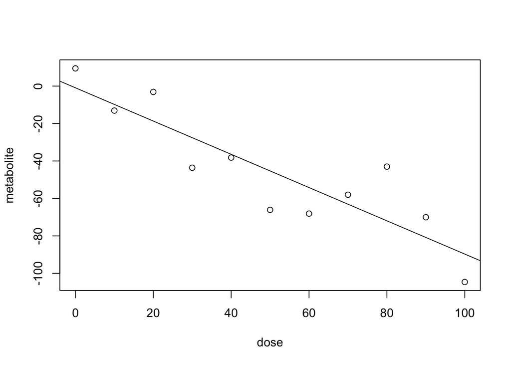

```r
plot(regression)
abline(lm.dose)
```

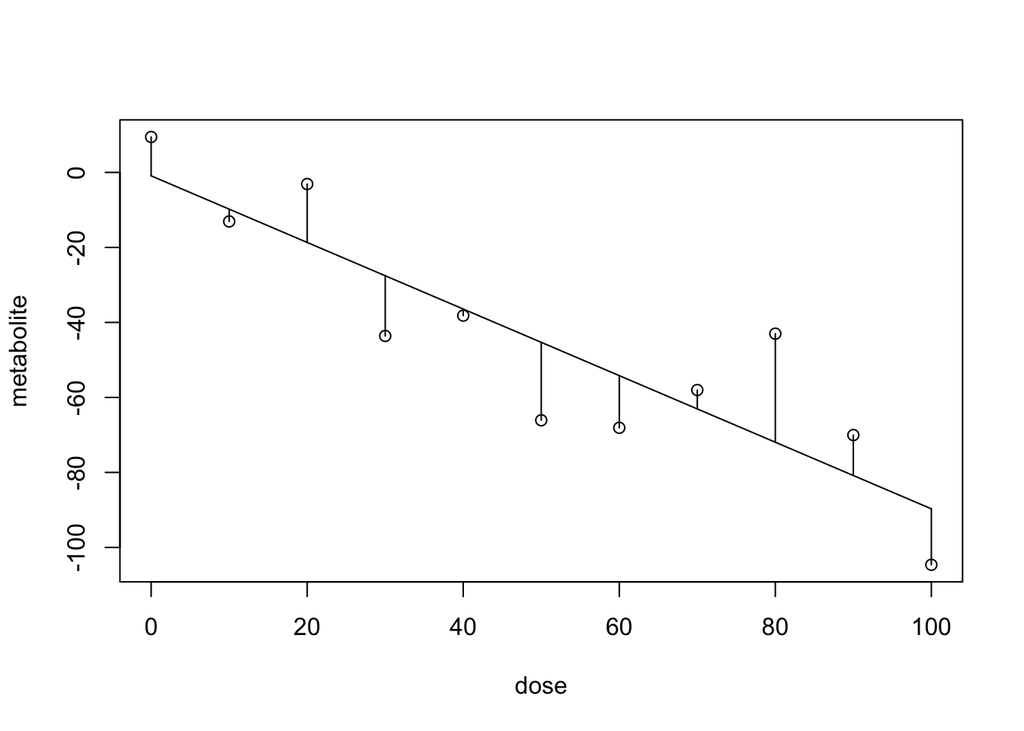

```r
plot(regression) #A scatter plot
lines(regression$dose, fitted(lm.dose))
segments(regression$dose, fitted(lm.dose),
         regression$dose, regression$metabolite)
```

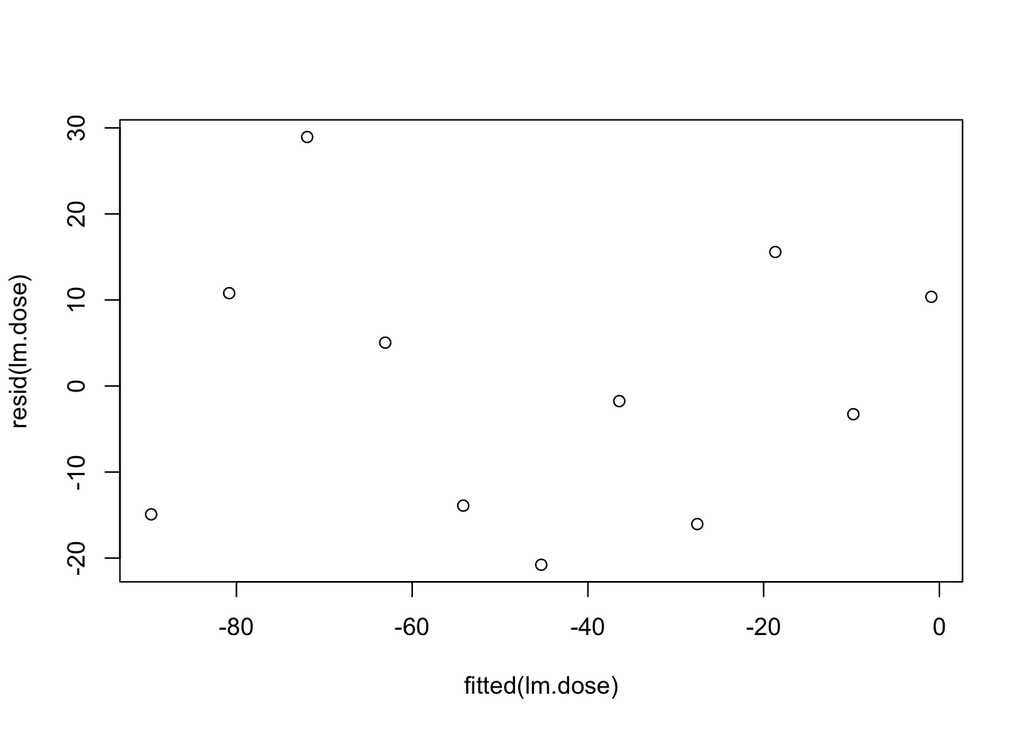

```r
plot(fitted(lm.dose),resid(lm.dose))
```

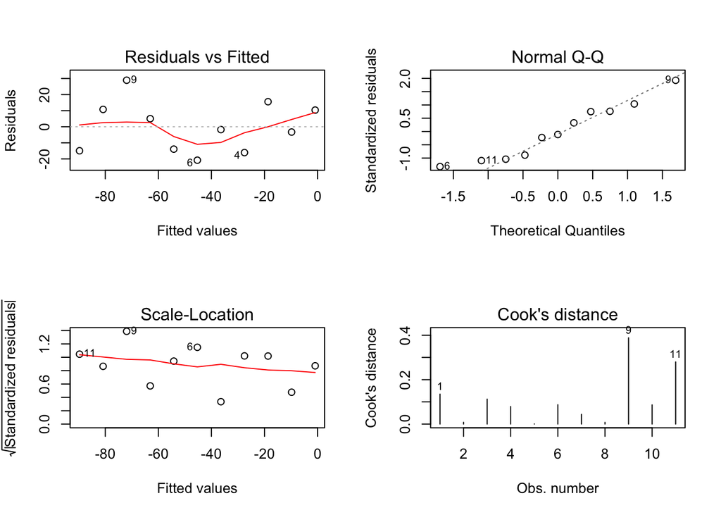

```r
par(mfrow=c(2,2))
plot(lm.dose, which=1:4)
```

It looks like data point 9 is very important for the model based on the Cook’s distance, but it seems like an outlier compared to the rest of the data points. I will try to re-run the linear regression removing observation 9. On the Residuals vs Fitted chart, it looks roughly like y=0 except near the middle, but that may be fine. The Normal Q-Q chart looks roughtly like a straight line, which is good. The Scale-Location chart shows no clear trend, which is also good.

```r
summary(lm(metabolite~dose, data=regression, subset=-9))
```

```
##
## Call:
## lm(formula = metabolite ~ dose, data = regression, subset = -9)
##
## Residuals:
##     Min      1Q  Median      3Q     Max
## -17.600  -9.072  -1.724   9.786  17.784
##
## Coefficients:
##             Estimate Std. Error t value Pr(>|t|)
## (Intercept)   0.6767     7.5872   0.089    0.931
## dose         -0.9833     0.1339  -7.343 8.05e-05 ***
## ---
## Signif. codes:  0 '***' 0.001 '**' 0.01 '*' 0.05 '.' 0.1 ' ' 1
##
## Residual standard error: 13.4 on 8 degrees of freedom
## Multiple R-squared:  0.8708, Adjusted R-squared:  0.8546
## F-statistic: 53.92 on 1 and 8 DF,  p-value: 8.048e-05
```

Removing observation 9 changed the p-value from 0.0003 to 8.1x10^-5. It seems observation 9 is very important to the linear model but as an outlier. The analysis does not hinge on a single observation.